# Advanced Methods for Regression and Classification - Exercise 7 Experiment - Dzenan Hamzic, TU Wien

## Data 1:Bone Mineral Density Data

Measurements in the bone mineral density of 261 north american adolescents, as function of age. Each value is the difference in spnbmd taken on two consecutive visits, divided by the average. The age is the average age over the two visits.

## Data 2: Surface temperature of stars and their light intensity

The Hertzsprung–Russell diagram, abbreviated as H–R diagram, HR diagram or HRD, is a scatter plot of stars showing the relationship between the stars’ absolute magnitudes or luminosities versus their stellar classifications or effective temperatures. https://en.wikipedia.org/wiki/Hertzsprung%E2%80%93Russell_diagram

## 1.

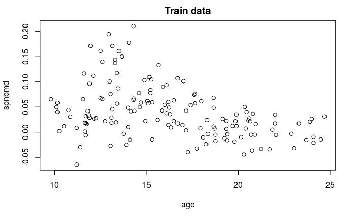

```r
library(ElemStatLearn)
data(bone)
d <- bone[bone$gender=="male",c("age","spnbmd")]
n <- nrow(d)
set.seed(123)
train <- sample(1:n,round(2/3*n))
test <- c(1:n)[-train]
plot(d[train,], main="Train data")
```

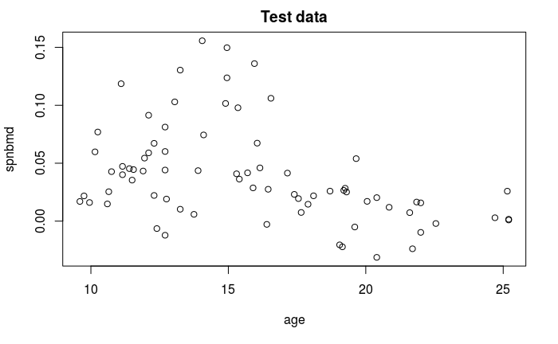

```r
plot(d[test,], main="Test data")
```

### 1.a)

```r
train_data <- d[train,]
test_data <- d[test,]
m1 <- smooth.spline(train_data$age, train_data$spnbmd, cv=TRUE)
```

```
cross-validation with non-unique 'x' values seems doubtful
```

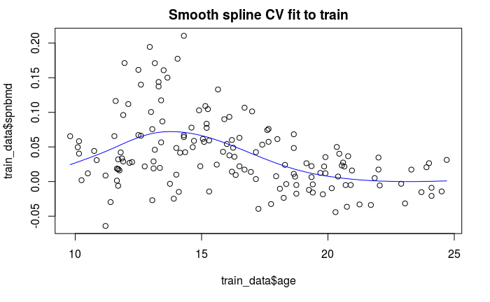

```r
plot(train_data$age, train_data$spnbmd, main="Smooth spline CV fit to train")
lines(m1, col="blue")
```

```r
#Error in plot.xy(xy.coords(x, y), type = type, ...) : plot.new has not been called yet
```

```r
predicted_m1 <- predict(m1, x=test_data$age)
mean((predicted_m1$y - test_data$spnbmd)^2)
```

```
[1] 0.00113546
```

smooth.splines with CV chooses automatically number of spline basis functions. BS splines with df=5 from last exercise had MSE of 0.00119171. NS splines with df=5 MSE was 0.001585333.